# Case Study - Machine Learning in R

Daisy Zhuo

Aug 30, 2017

In the first session, we were introduced to how to import, tidy, transform, visualize, and communicate. But what about modeling? What can we achieve with sophisticated models that we can’t do with summaries and descriptive statistics? In this case study, we’ll build on your data wrangling skills and introduce modeling, giving you familiarity with every stage of the data scientific process.

## Regression

Within the world of supervised learning, we can divide tasks into two parts. In settings where the response variable is continuous we call the modelling *regression*, and when the response is categorical we call it *classification*. We will begin with regression to understand what factors influence price in the AirBnB data set.

### Data Exploration

Let’s start by loading the data (after first setting the correct working directory). We’ll use the ‘listings.csv’ file for now. Since we’ll be wrangling and visualizing, we’ll also load the `tidyverse` package. (Instead of `tidyverse`, it also works to load `tidyr`, `dplyr`, and `ggplot2` as we saw last session.)

```r
library(tidyverse)
listings <- read_csv("../data/listings.csv")
```

As a review, we need to change the price column to a numeric form.

```r
listings <- listings %>% mutate(price = as.numeric(gsub("\\$|,","",price)))
summary(listings$price) # Check to make sure things worked
```

```
##    Min. 1st Qu.  Median    Mean 3rd Qu.    Max.
##    10.0    85.0   150.0   173.9   220.0  4000.0
```

Now, which variables may be predictive of price? We can use `names(listings)` to get a look at all the variable names.

#### EXERCISE 1: LOOK AT DATA

- Take 15 minutes to come up with your conceptual predictive models for the price, keep the following in mind:
- Which factors influence price?
- Should the relationship be linear?
- Should variables be transformed?
- Advanced: additional data to be joined on?
- Use visualization, data summary from the morning to explore

```r
listings_for_lm <-listings %>%
  filter(accommodates <= 10, price <=1000)
```

### Regression Model Training

You easily can add a linear fit to a scatter plot easily by adding geom_smooth with method=“lm”:

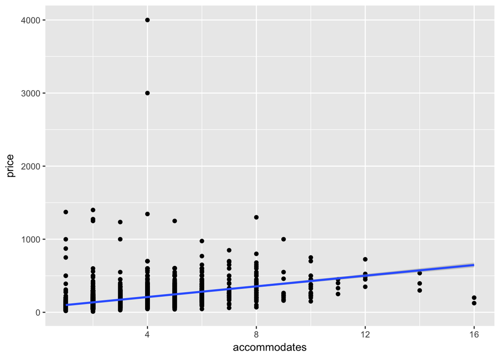

```r
listings %>%
  ggplot() +
  aes(x=accommodates, y=price) +
  geom_point() +
  geom_smooth(method="lm")
```

What if we need to quantify the linear fit, check it statistical significance, extend to multiple variables, and make predictions? A more rigorous statistical procedure is therefore needed. Since we care about prediction accuracy, we’ll reserve a portion of our data to be a test set. There are lots of ways to do this. We’ll use the `modelr` package, which is part of the `tidyverse`.

```r
library(modelr) # Comes with tidyverse installation, but doesn't automatically load with the library(tidyverse) call
set.seed(1)  # Keep the random partition the same for multiple runs
listings_part <-listings_for_lm %>%
  resample_partition(c(train=0.7,test=0.3))
listings_part
```

```
## $train
## <resample [2,492 x 95]> 1, 2, 3, 5, 8, 9, 10, 11, 12, 13, ...
##
## $test
## <resample [1,069 x 95]> 4, 6, 7, 15, 17, 18, 20, 21, 25, 29, ...
```

In R, we specify a model structure and then use the corresponding function to tell R to optimize for the best-fitting model. For linear regression, the function is `lm()`:

```r
lm_price_by_acc <-lm(price ~ accommodates,data=listings_part$train) # We'll talk more about the '~' notation soon
```

Let’s check out the lm_price_by_acc object:

```r
names(lm_price_by_acc)
```

```
##  [1] "coefficients"  "residuals"     "effects"       "rank"
##  [5] "fitted.values" "assign"        "qr"            "df.residual"
##  [9] "xlevels"       "call"          "terms"         "model"
```

The object `lm_price_by_acc` is a list of a bunch of relevant information generated by the `lm()` function call. We can use the `$` to view different elements, for example

```r
lm_price_by_acc$call
```

```
## lm(formula = price ~ accommodates, data = listings_part$train)
```

So, it stores the function call in one of the list elements. But this isn’t the most useful way to check out the model fit. The function `summary()` is overloaded for many different objects and often gives a useful snapshot of the model:

```r
summary(lm_price_by_acc)
```

```
##
## Call:
## lm(formula = price ~ accommodates, data = listings_part$train)
##
## Residuals:
##     Min      1Q  Median      3Q     Max
## -291.47  -55.89  -18.61   41.25  906.54
##
## Coefficients:
##              Estimate Std. Error t value Pr(>|t|)
## (Intercept)    54.029      3.826   14.12   <2e-16 ***
## accommodates   38.431      1.118   34.38   <2e-16 ***
## ---
## Signif. codes:  0 '***' 0.001 '**' 0.01 '*' 0.05 '.' 0.1 ' ' 1
##
## Residual standard error: 92.4 on 2490 degrees of freedom
## Multiple R-squared:  0.3219, Adjusted R-squared:  0.3217
## F-statistic:  1182 on 1 and 2490 DF,  p-value: < 2.2e-16
```

There we go, this is more useful! First, let’s look at the section under “Coefficients”. Notice that R automatically adds an intercept term unless you tell it not to (we’ll see how to do this later). In the “estimate” column, we see that the point estimates for the linear model here say that the price is $54.03 plus $38.43 for every person accommodated. Notice the ’***’ symbols at the end of the “(Intercept)” and “accommodates” rows. These indicate that according to a statistical t-test, both coefficients are extremely significantly different than zero, so things are okay from an inference perspective.

### Model evaluation

#### EXERCISE 2: VISUALIZE MODEL PERFORMANCE

There are some nifty functions in the `modelr` package that make interacting with models easy in the `tidyr` and `dplyr` setting. We’ll use `modelr::add_predictions()` here. We can also remove the linear trend and check the residual uncertainty, which we’ll do here using `modelr::add_residuals()`.

```r
listing_with_pred <-  as.data.frame(listings_part$train) %>%
  add_predictions(lm_price_by_acc) %>%
  add_residuals(lm_price_by_acc,var="resid")
```

- How would you visualize the model fit? Spend 10 minutes to come up with your visualizations Now, what if we wanted to *quantify* how well the model predicts these out-of-sample values? There are several metrics to aggregate the prediction error. We’ll look at RMSE, MAE, and Rsquared. You could do this pretty easily by hand, and we’ll do so later on, but `modelr` has built-in functions to do this for you:

```r
rmse(lm_price_by_acc,listings_part$test)
```

```
## [1] 94.04158
```

```r
mae(lm_price_by_acc,listings_part$test)
```

```
## [1] 64.47539
```

```r
rsquare(lm_price_by_acc,listings_part$test)
```

```
## [1] 0.3389596
```

These don’t help much on their own, but they come in handy when comparing different models, which we’ll do next after a quick review.  
We interacted with the model to evaluate goodness-of-fit and out-of-sample performance. In our case, we used the `modelr` and `dplyr` framework to do this cleanly.

### Adding More Variables

Let’s work a bit harder on predicting price, this time using more than one predictor. In fact, we’ll add a bunch of predictors to the model and see what happens.  
As one set of predictors, the column listings$amenities looks interesting:

```r
listings %>% select(amenities) %>% head()
```

```
## # A tibble: 6 x 1
##                                                                     amenities
##                                                                         <chr>
## 1 "{TV,\"Wireless Internet\",Kitchen,\"Free Parking on Premises\",\"Pets live
## 2 "{TV,Internet,\"Wireless Internet\",\"Air Conditioning\",Kitchen,\"Pets All
## 3 "{TV,\"Cable TV\",\"Wireless Internet\",\"Air Conditioning\",Kitchen,\"Free
## 4 "{TV,Internet,\"Wireless Internet\",\"Air Conditioning\",Kitchen,\"Free Par
## 5 "{Internet,\"Wireless Internet\",\"Air Conditioning\",Kitchen,Breakfast,Hea
## 6 "{\"Cable TV\",\"Wireless Internet\",\"Air Conditioning\",Kitchen,\"Free Pa
```

This could be good predictive information if we can separate out which listing has which amenity. Our goal here is to turn the amenities column into many columns, one for each amenity, and with logical values indicating whether each listing has each amenity. This is just a bit tricky with some text manipulation. You can just include the code below and trust me on it.

```r
listings <-listings %>%
  filter(!grepl("translation missing",amenities)) %>%
  mutate(amenities=gsub("[{}]|\"|[()]|-","",amenities)) %>%
  mutate(amenities=gsub(" |/","_",amenities)) %>%
  mutate(amenities=gsub("24","x24",amenities))

# Then, split the strings by amenity and create new column
splitting <-strsplit(listings$amenities,",")
all_amenities <-Reduce(union,splitting)
for (i in all_amenities){
  listings[paste("amenity_",i,sep="")] <-grepl(i,listings$amenities)
}
```

Before building the model, let’s clean up the data by getting rid of missing values and outliers. For categorical variables, we will remove all categories with only a few observations. Finally, we’ll separate again into training and test sets.

```r
listings_big <- listings %>%
  filter(!is.na(review_scores_rating),
         accommodates <= 10,
         property_type %in% c("Apartment","House","Bed & Breakfast","Condominium","Loft","Townhouse"),
         !(neighbourhood_cleansed %in% c("Leather District","Longwood Medical Area")),
         price <= 1000) %>%
  select(price,accommodates,room_type,property_type,review_scores_rating,neighbourhood_cleansed,starts_with("amenity"))
```

note the use `starts_with` as a handy shortcut to select groups of variables

#### EXERCISE 3: BUILD NEW LINEAR MODELS

- Work with your partner, build your next linear model with multiple variables.
  - Clean the data first if necessary (remove missing observations, etc.)
  - Remember the formula syntax
  - Use some of the amenity variables we just created
  - Consider interactions and transformation of variables
  - Don’t forget to do the train/test split
- Generate model performance measures and compare with our first model
- Visualize data and results

### LASSO (Penalized regression)

But is there still a way to use the info from all these variables without overfitting? Yes! One way to do this is by regularized, or penalized, regression. To do LASSO, we’ll use the `glmnet` package. Of note, this package doesn’t work very elegantly with the `tidyverse` since it uses matrix representations of the data rather than data frame representations. However, it does what it does quite well, and will give us a chance to see some base R code. Let’s load the package and check out the function `glmnet()`. We can see the documentation from the command line using `?glmnet`.

```r
library(glmnet)
```

Notice that `glmnet()` doesn’t communicate with the data via formulas. Instead, it wants a matrix of predictor variables and a vector of values for the variable we’re trying to predict, including all the categorical variables that R automatically expanded into indicator variables. Fortunately, R has a `model.matrix()` function which takes a data frame and gets it into the right form for `glmnet()` and other functions with this type of input.  
Notice also that there’s a way to specify lambda manually. Since we haven’t discussed choosing lambda yet, let’s just accept the default for now and see what we get.  
Make sure you run the following:

```r
listings_big_lm <- listings_big %>%
  resample_partition(c(train=0.7,test=0.3))

x <- model.matrix(~ .-price + accommodates*room_type + property_type*neighbourhood_cleansed + review_scores_rating*neighbourhood_cleansed + accommodates*review_scores_rating,data=as.data.frame(listings_big_lm$train))
y <- as.vector(as.data.frame(listings_big_lm$train)$price)
lasso_price <- glmnet(x,y)
```

This time the `summary()` function isn’t quite as useful:

```r
summary(lasso_price)
```

```
##           Length Class     Mode
## a0          100  -none-    numeric
## beta      21000  dgCMatrix S4
## df          100  -none-    numeric
## dim           2  -none-    numeric
## lambda      100  -none-    numeric
## dev.ratio   100  -none-    numeric
## nulldev       1  -none-    numeric
## npasses       1  -none-    numeric
## jerr          1  -none-    numeric
## offset        1  -none-    logical
## call          3  -none-    call
## nobs          1  -none-    numeric
```

It does give us some info, though. Notice that “lambda” is a vector of length 100. The `glmnet()` function has defined 100 different values of lambda and found the corresponding optimal beta vector for each one! We have 100 different models here. Let’s look at some of the coefficients for the different models. We’ll start with one where lambda is really high:

```r
lasso_price$lambda[1]
```

```
## [1] 69.31479
```

```r
nnzero(lasso_price$beta[,1]) # How many coefficients are nonzero?
```

```
## [1] 0
```

Here the penalty on the size of the coefficients is so high that R sets them all to zero. Moving to some smaller lambdas:

```r
lasso_price$lambda[10]
```

```
## [1] 30.00472
```

```r
lasso_price$beta[which(lasso_price$beta[,10] != 0),10]
```

```
##             room_typePrivate room accommodates:review_scores_rating
##                       -35.7437109                         0.1947848
```

```r
lasso_price$lambda[20]
```

```
## [1] 11.83448
```

```r
lasso_price$beta[which(lasso_price$beta[,20] != 0),20]
```

```
##                                 room_typePrivate room
##                                          -28.88130245
##                        neighbourhood_cleansedBack Bay
##                                            7.12540286
##                                        amenity_TVTRUE
##                                            0.96652016
##                  amenity_Free_Parking_on_PremisesTRUE
##                                           -5.01419276
##                          amenity_Air_ConditioningTRUE
##                                            4.31292591
##                          amenity_Indoor_FireplaceTRUE
##                                            2.91149473
##                                  amenity_Cable_TVTRUE
##                                            9.60928061
##                      amenity_Elevator_in_BuildingTRUE
##                                           18.09944292
##                    accommodates:room_typePrivate room
##                                          -10.02955100
##  property_typeHouse:neighbourhood_cleansedBeacon Hill
##                                           30.43384693
## review_scores_rating:neighbourhood_cleansedDorchester
##                                           -0.02463174
##                     accommodates:review_scores_rating
##                                            0.28281011
```

And, to see the whole path of lambdas:

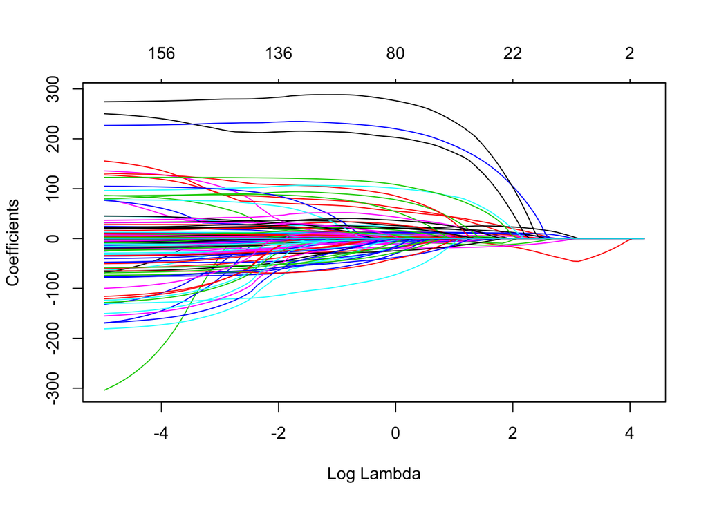

```r
plot.glmnet(lasso_price,xvar="lambda")
```

Here, each line is one variable. The plot is quite messy with so many variables, but it gives us the idea. As lambda shrinks, the model adds more and more nonzero coefficients.

### Cross Validation

```r
set.seed(1)
lasso_price_cv <- cv.glmnet(x,y)
summary(lasso_price_cv) # What does the model object look like?
```

```
##            Length Class  Mode
## lambda     91     -none- numeric
## cvm        91     -none- numeric
## cvsd       91     -none- numeric
## cvup       91     -none- numeric
## cvlo       91     -none- numeric
## nzero      91     -none- numeric
## name        1     -none- character
## glmnet.fit 12     elnet  list
## lambda.min  1     -none- numeric
## lambda.1se  1     -none- numeric
```

```r
lasso_price_cv$lambda.min
```

```
## [1] 1.268972
```

Notice the “lambda.min”. This is the best lambda as determined by the cross validation. “lambda.1se” is the largest lambda such that the “error is within 1 standard error of the minimum.” There’s another automatic plotting function for `cv.glmnet()` which shows the error for each model:

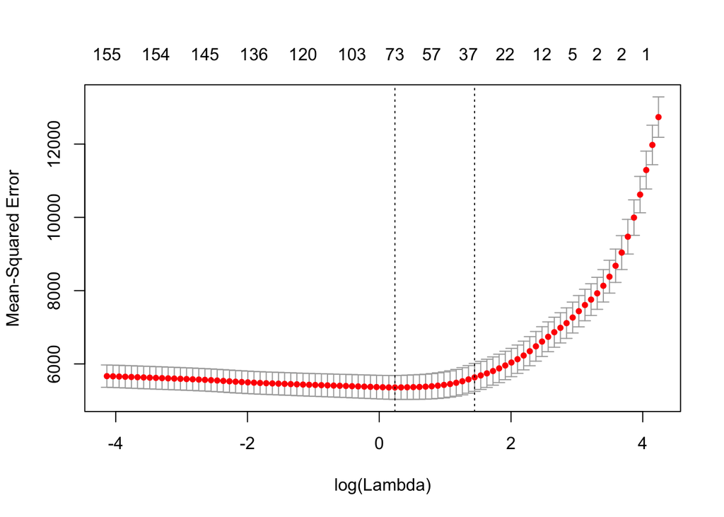

```r
plot.cv.glmnet(lasso_price_cv)
```

The first vertical dotted line shows `lambda.min`, and the second is `lambda.1se`. The figure illustrates that we cross-validate to find the “sweet spot” where there’s not too much bias (high lambda) and not too much noise (low lambda). Let’s again compare training and test error. Since the `predict()` function for `glmnet` objects uses matrices, we can’t use the `rmse` function like we did before.

```r
x_all <- model.matrix(~ .-price + accommodates*room_type + property_type*neighbourhood_cleansed + review_scores_rating*neighbourhood_cleansed + accommodates*review_scores_rating,data=listings_big) # Matrix form for combined test and training data

lasso.pred <- predict.cv.glmnet(lasso_price_cv,newx=x_all, s="lambda.min")

listings_big %>%
  mutate(is_test = 1:nrow(listings_big) %in% listings_big_lm$test$idx,
         pred = lasso.pred) %>%
  group_by(is_test) %>%
  summarize(rmse <- sqrt(1/length(price)*sum((price-pred)^2)))
```

```
## # A tibble: 2 x 2
##   is_test `rmse <- sqrt(1/length(price) * sum((price - pred)^2))`
##     <lgl>                                                   <dbl>
## 1   FALSE                                                68.27384
## 2    TRUE                                                71.25230
```

The overfitting problem has gotten better, but hasn’t yet gone away completely. I added a bunch variables for dramatic effect that we could probably screen out before running the LASSO if we really wanted a good model.  
One more note on cross-validation: the `glmnet` package has built-in functionality for cross-validation. In situations where that’s not the case, `modelr::crossv_kfold()` will prepare data for cross validation in a nice way.

## Classification

So far we’ve looked at models which predict a continuous response variable. There are many related models which predict categorical outcomes, such as whether an email is spam or not, or which digit a handwritten number is. We’ll take a brief look at example of this: logistic regression.

In this example, we will be working with the Titanic data where the survival status of passengers, as well as other information such as class, demographics, and fare are provided. Let’s read in the Titanic data

```r
titanic <- read_csv("../data/titanic.csv")
```

check data:

```r
glimpse(titanic)
```

```
## Observations: 891
## Variables: 12
## $ PassengerId <int> 1, 2, 3, 4, 5, 6, 7, 8, 9, 10, 11, 12, 13, 14, 15,...
## $ Survived    <int> 0, 1, 1, 1, 0, 0, 0, 0, 1, 1, 1, 1, 0, 0, 0, 1, 0,...
## $ Pclass      <int> 3, 1, 3, 1, 3, 3, 1, 3, 3, 2, 3, 1, 3, 3, 3, 2, 3,...
## $ Name        <chr> "Braund, Mr. Owen Harris", "Cumings, Mrs. John Bra...
## $ Sex         <chr> "male", "female", "female", "female", "male", "mal...
## $ Age         <dbl> 22, 38, 26, 35, 35, NA, 54, 2, 27, 14, 4, 58, 20, ...
## $ SibSp       <int> 1, 1, 0, 1, 0, 0, 0, 3, 0, 1, 1, 0, 0, 1, 0, 0, 4,...
## $ Parch       <int> 0, 0, 0, 0, 0, 0, 0, 1, 2, 0, 1, 0, 0, 5, 0, 0, 1,...
## $ Ticket      <chr> "A/5 21171", "PC 17599", "STON/O2. 3101282", "1138...
## $ Fare        <dbl> 7.2500, 71.2833, 7.9250, 53.1000, 8.0500, 8.4583, ...
## $ Cabin       <chr> NA, "C85", NA, "C123", NA, NA, "E46", NA, NA, NA, ...
## $ Embarked    <chr> "S", "C", "S", "S", "S", "Q", "S", "S", "S", "C", ...
```

#### EXERCISE 4: EXPLORE ON YOUR OWN

Take 20 minutes, working with your partner, construct a logistic regression model to predict `Survived` variables.

```r
#
```

- Visualize data to generate hypothesis
- Transform data to engineer additional features
- Make sure to split training and testing. What do you think we should use to evaluate binary predictions?